# Homework1_ie360

Ali Seyit Zararsız

18.04.2021

In this study, I investigate three measures of Turkey and their relatable keywords over google. Topics are exchange rates of US Dollar/Turkish Lira and “dolar ne kadar” keyword, consumer price index and “enflasyon” keyword, house sales in Turkey and “satilik ev” keyword.

All data are taken from EVDS and google trends. If you want to check their websites please click [here](https://evds2.tcmb.gov.tr/) for EVDS and [here](https://trends.google.com/trends/) for google trends.

## 1) Exchange Rate of US Dollar/Turkish Lira

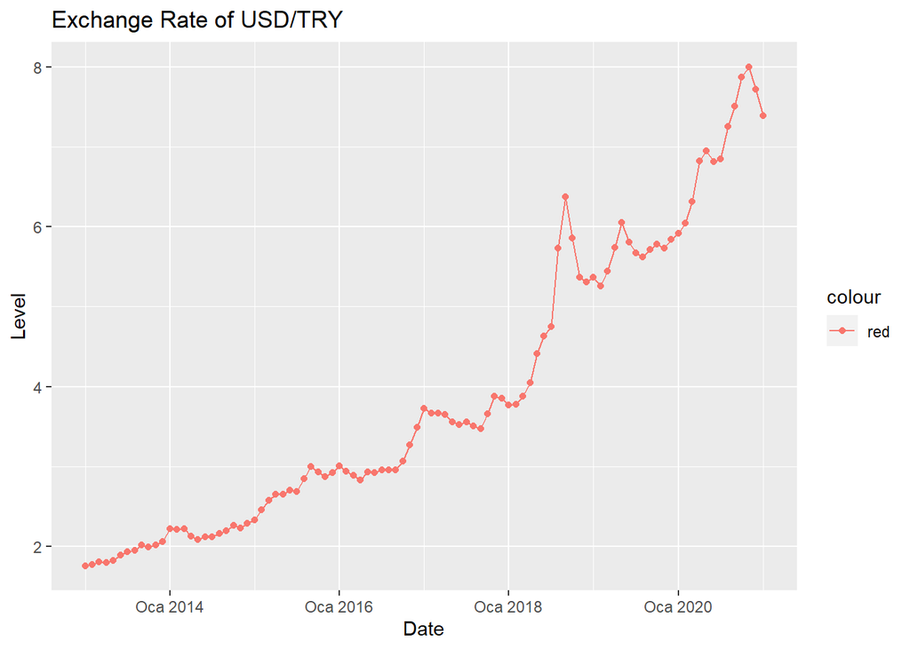

Here we can easily see that beginning from our observations this exchange rate has continuously increased over the years. This may show Turkey’s economic situation with respect to US. Biggest jump in the time series happened in 2018 due to an economical crisis.

[figure not shown]

In this graph year 2018 grabs your attention, as I remember correctly, whole nation checks the dollar exchange rate frequently during that big spike. It matches perfectly with this observations.

## 2) Consumer Price Index for Turkey (Base 2003=100)

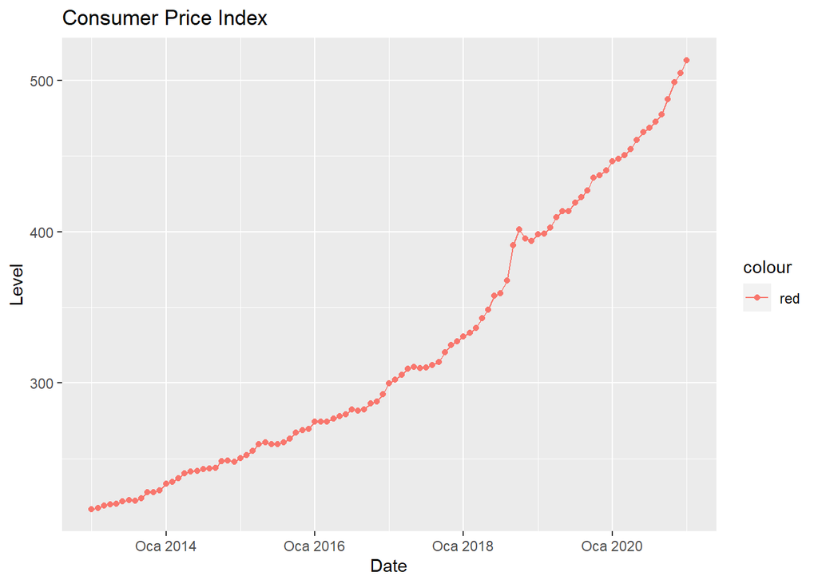

Turkey’s general economic position in the last years has been losing power significantly. Most people can not afford their so called “baskets”. In this time series data you may see that price levels has gone upwards almost everytime. This has to be a result of inflation over the years.

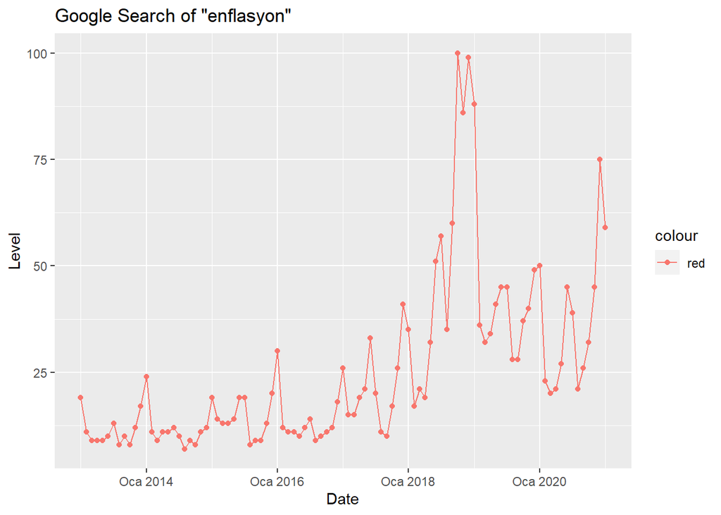

In this time series data we can observe some seasonality. Each year there are some expectations about the inflation levels, after the announcement of official inflation level people want to compare this level to their daily lives. Highest points of the line are usually first and sixth months of a year, just as the time inflation is announced. Lastly the big spike in 2018 was a result of the fear in nation’s thoughts due to the economical crisis.

## 3) House Sales of All Regions in Turkey

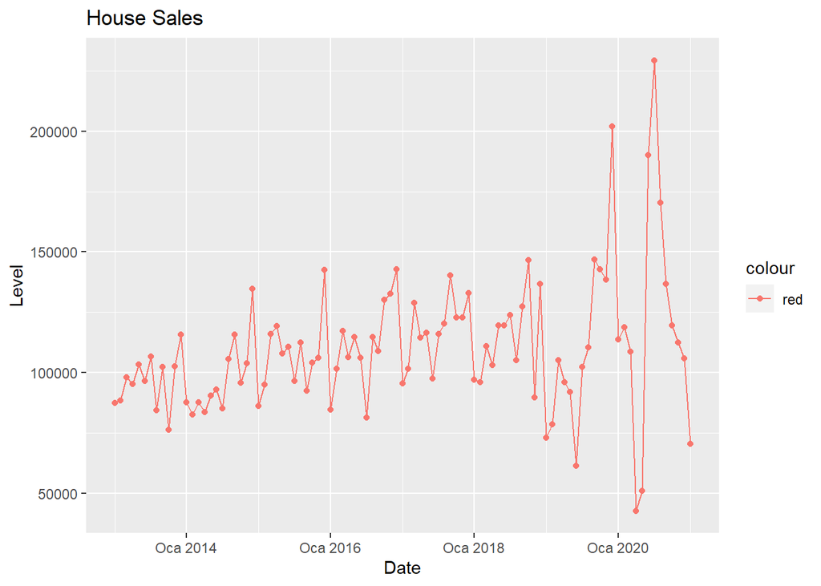

In the house sales time series data, anyone can say it is not stable. This data is highly related with the house loans, housing sector, urban transformation and zoning laws. However fluctuations after the third quarter of 2019 are abnormally high. First the sales rose with high loans than hit bottom with Dr. Koca announcing the first victim with an coronavirus. Almost every sector has taken huge damages and government has to do some corrections which starts with highering the rates again. I think this cycle will continue and can change any moment with government decisions.

[figure not shown]

## References

[Google Trends](https://trends.google.com/trends/?geo=US)

[EVDS](https://evds2.tcmb.gov.tr/index.php)